# INN Hotels Project

[figure not shown]

```python
# Let's look at the tree
plt.figure(figsize=(17,15))

tree.plot_tree(best_model,feature_names=feature_names,filled=True,fontsize=9,node_ids=True,class_names=True)
plt.show()
```

```python
# Text report
print(tree.export_text(best_model,feature_names=feature_names,show_weights=True))
```

```
|--- lead_time <= 151.50
|   |--- no_of_special_requests <= 0.50
|   |   |--- market_segment_type_Online <= 0.50
|   |   |   |--- lead_time <= 90.50
|   |   |   |   |--- no_of_weekend_nights <= 1.50
|   |   |   |   |   |--- avg_price_per_room <= 202.00
|   |   |   |   |   |   |--- no_of_weekend_nights <= 0.50
|   |   |   |   |   |   |   |--- market_segment_type_Offline <= 0.50
|   |   |   |   |   |   |   |   |--- repeated_guest <= 0.50
|   |   |   |   |   |   |   |   |   |--- avg_price_per_room <= 87.25
|   |   |   |   |   |   |   |   |   |   |--- market_segment_type_Corporate <= 0.50
|   |   |   |   |   |   |   |   |   |   |   |--- weights: [54.29, 0.00] class: 0
|   |   |   |   |   |   |   |   |   |   |--- market_segment_type_Corporate >  0.50
|   |   |   |   |   |   |   |   |   |   |   |--- truncated branch of depth 6
|   |   |   |   |   |   |   |   |   |--- avg_price_per_room >  87.25
|   |   |   |   |   |   |   |   |   |   |--- lead_time <= 1.50
|   |   |   |   |   |   |   |   |   |   |   |--- weights: [38.67, 1.53] class: 0
|   |   |   |   |   |   |   |   |   |   |--- lead_time >  1.50
|   |   |   |   |   |   |   |   |   |   |   |--- truncated branch of depth 5
|   |   |   |   |   |   |   |   |--- repeated_guest >  0.50
|   |   |   |   |   |   |   |   |   |--- weights: [130.88, 0.00] class: 0
|   |   |   |   |   |   |   |--- market_segment_type_Offline >  0.50
|   |   |   |   |   |   |   |   |--- weights: [1226.99, 0.00] class: 0
|   |   |   |   |   |   |--- no_of_weekend_nights >  0.50
|   |   |   |   |   |   |   |--- lead_time <= 65.50
|   |   |   |   |   |   |   |   |--- avg_price_per_room <= 116.02
|   |   |   |   |   |   |   |   |   |--- avg_price_per_room <= 48.17
|   |   |   |   |   |   |   |   |   |   |--- avg_price_per_room <= 47.10
|   |   |   |   |   |   |   |   |   |   |   |--- weights: [23.05, 1.53] class: 0
|   |   |   |   |   |   |   |   |   |   |--- avg_price_per_room >  47.10
|   |   |   |   |   |   |   |   |   |   |   |--- weights: [0.00, 10.68] class: 1
|   |   |   |   |   |   |   |   |   |--- avg_price_per_room >  48.17
|   |   |   |   |   |   |   |   |   |   |--- weights: [463.28, 53.42] class: 0
|   |   |   |   |   |   |   |   |--- avg_price_per_room >  116.02
|   |   |   |   |   |   |   |   |   |--- avg_price_per_room <= 118.33
|   |   |   |   |   |   |   |   |   |   |--- weights: [0.00, 6.10] class: 1
|   |   |   |   |   |   |   |   |   |--- avg_price_per_room >  118.33
|   |   |   |   |   |   |   |   |   |   |--- arrival_year <= 2017.50
|   |   |   |   |   |   |   |   |   |   |   |--- truncated branch of depth 2
|   |   |   |   |   |   |   |   |   |   |--- arrival_year >  2017.50
```

[output cut: 702 more lines]

```
|   |   |   |   |   |   |   |   |   |--- weights: [2.97, 0.00] class: 0
|   |--- avg_price_per_room >  100.04
|   |   |--- arrival_month <= 11.50
|   |   |   |--- no_of_special_requests <= 2.50
|   |   |   |   |--- weights: [0.00, 3189.64] class: 1
|   |   |   |--- no_of_special_requests >  2.50
|   |   |   |   |--- weights: [24.54, 0.00] class: 0
|   |   |--- arrival_month >  11.50
|   |   |   |--- no_of_special_requests <= 0.50
|   |   |   |   |--- weights: [40.16, 0.00] class: 0
|   |   |   |--- no_of_special_requests >  0.50
|   |   |   |   |--- arrival_date <= 8.00
|   |   |   |   |   |--- weights: [2.97, 0.00] class: 0
|   |   |   |   |--- arrival_date >  8.00
|   |   |   |   |   |--- weights: [6.69, 27.47] class: 1
```

```python
# importance of features in the tree building
# Gini importance: total reduction of criterion brought by that feature
print (pd.DataFrame(best_model.feature_importances_, columns = ["Imp"], index = x_train.columns).sort_values(by = 'Imp', ascending = False))
```

```
                                           Imp
lead_time                             0.388145
market_segment_type_Online            0.130874
no_of_special_requests                0.122669
avg_price_per_room                    0.119255
arrival_month                         0.063121
arrival_date                          0.040094
no_of_adults                          0.030853
no_of_weekend_nights                  0.027898
no_of_week_nights                     0.022464
arrival_year                          0.020917
required_car_parking_space            0.009643
market_segment_type_Offline           0.005366
type_of_meal_plan_Not Selected        0.004417
type_of_meal_plan_Meal Plan 2         0.003070
no_of_children                        0.002600
room_type_reserved_Room_Type 4        0.002191
room_type_reserved_Room_Type 2        0.001975
market_segment_type_Corporate         0.001892
repeated_guest                        0.001537
room_type_reserved_Room_Type 5        0.000738
room_type_reserved_Room_Type 7        0.000281
no_of_previous_bookings_not_canceled  0.000000
no_of_previous_cancellations          0.000000
type_of_meal_plan_Meal Plan 3         0.000000
room_type_reserved_Room_Type 3        0.000000
room_type_reserved_Room_Type 6        0.000000
market_segment_type_Complementary     0.000000
const                                 0.000000
```

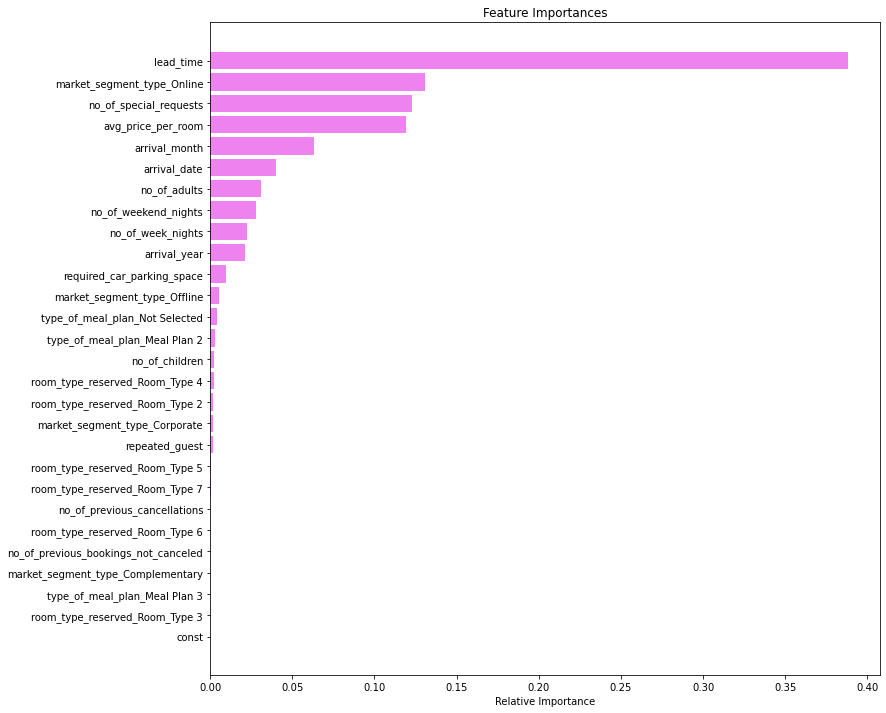

```python
importances = best_model.feature_importances_
indices = np.argsort(importances)

plt.figure(figsize=(12,12))
plt.title('Feature Importances')
plt.barh(range(len(indices)), importances[indices], color='violet', align='center')
plt.yticks(range(len(indices)), [feature_names[i] for i in indices])
plt.xlabel('Relative Importance')
plt.show()
```

```python
# Compare the performance of pre and post pruning of decision trees
models_train_comp_df = pd.concat(
    [
        decision_tree1_train.T,
        decision_tree2_train.T,
    ],
    axis=1,
)
models_train_comp_df.columns = [
    "Decision Tree (Pre-Pruning)",
    "Decision Tree (Post-Pruning)",
]
print("Training performance comparison:")
models_train_comp_df

# Pre-pruning of decision tree is so much higher in terms of:
# accuracy, recall, precision, and F1
```

```
Training performance comparison:
```

|  | Decision Tree (Pre-Pruning) | Decision Tree (Post-Pruning) |
| --- | --- | --- |
| Accuracy | 0.994368 | 0.909853 |
| Recall | 0.985695 | 0.918740 |
| Precision | 0.997082 | 0.825735 |
| F1 | 0.991356 | 0.869758 |

Performance metrics of final model

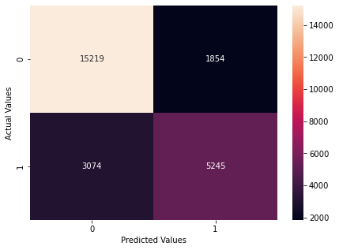

```python
cm = confusion_matrix(y_train.astype(int), pred_train2)
plt.figure(figsize=(7, 5))
sns.heatmap(cm, annot=True, fmt="g")
plt.xlabel("Predicted Values")
plt.ylabel("Actual Values")
plt.show()
```

```python
accuracy_score(y_train.astype(int), pred_train2)
# The accuracy is not 100%, but in the high terms
```

```
0.8059231253938248
```

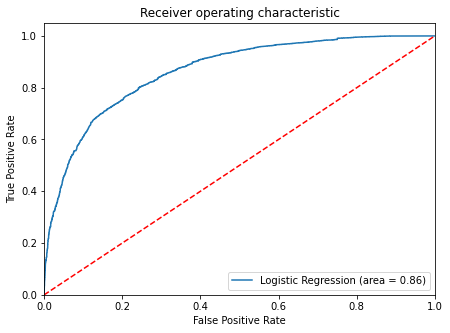

```python
logit_roc_auc_train = roc_auc_score(y_train.astype(float), lg2.predict(x_train2))
fpr, tpr, thresholds = roc_curve(y_train.astype(int), lg2.predict(x_train2))
plt.figure(figsize=(7, 5))
plt.plot(fpr, tpr, label="Logistic Regression (area = %0.2f)" % logit_roc_auc_train)
plt.plot([0, 1], [0, 1], "r--")
plt.xlim([0.0, 1.0])
plt.ylim([0.0, 1.05])
plt.xlabel("False Positive Rate")
plt.ylabel("True Positive Rate")
plt.title("Receiver operating characteristic")
plt.legend(loc="lower right")
plt.show()

# Model seems to performing pretty well on the training set.
# True Positive Rate: Tp/Tp+FN
# False positive Rate: Fp/FP+TN
# AUC (Area Under the ROC Curve) equals 0.86
```

That said we can use the model for making predictions

```python
# drop values also for test
x_test = x_test.drop(["no_of_adults", "market_segment_type_Offline"], axis=1)
```

```python
pred_test = lg2.predict(x_test) > 0.5
pred_test = np.round(pred_test)
```

```python
print("Accuracy on training set : ", accuracy_score(y_train.astype(int), pred_train2))
print("Accuracy on test set : ", accuracy_score(y_test.astype(int), pred_test))
# Accuracy is pretty high for the test and trainig
# and they are also very similar, so that the model does not only follow the training set
```

```
Accuracy on training set :  0.8059231253938248
Accuracy on test set :  0.8036387025636313
```

```python
final=sm.Logit(y_train.astype(int), x_train2).fit()
final.summary()
```

Logit Regression Results

| Dep. Variable: | booking_status | No. Observations: | 25392 |
| --- | --- | --- | --- |
| Model: | Logit | Df Residuals: | 25366 |
| Method: | MLE | Df Model: | 25 |
| Date: | Sat, 30 Jul 2022 | Pseudo R-squ.: | 0.3311 |
| Time: | 11:43:06 | Log-Likelihood: | -10742. |
| converged: | False | LL-Null: | -16060. |
| Covariance Type: | nonrobust | LLR p-value: | 0.000 |

|  | coef | std err | z | P>\|z\| | [0.025 | 0.975] |
| --- | --- | --- | --- | --- | --- | --- |
| const | -917.4169 | 120.919 | -7.587 | 0.000 | -1154.415 | -680.419 |
| no_of_children | 0.0774 | 0.060 | 1.283 | 0.199 | -0.041 | 0.196 |
| no_of_weekend_nights | 0.1507 | 0.020 | 7.606 | 0.000 | 0.112 | 0.190 |
| no_of_week_nights | 0.0389 | 0.012 | 3.168 | 0.002 | 0.015 | 0.063 |
| required_car_parking_space | -1.6009 | 0.137 | -11.680 | 0.000 | -1.870 | -1.332 |
| lead_time | 0.0156 | 0.000 | 59.270 | 0.000 | 0.015 | 0.016 |
| arrival_year | 0.4525 | 0.060 | 7.550 | 0.000 | 0.335 | 0.570 |
| arrival_month | -0.0465 | 0.006 | -7.171 | 0.000 | -0.059 | -0.034 |
| arrival_date | 0.0030 | 0.002 | 1.551 | 0.121 | -0.001 | 0.007 |
| repeated_guest | -1.8864 | 0.761 | -2.479 | 0.013 | -3.378 | -0.395 |
| no_of_previous_cancellations | 0.3414 | 0.102 | 3.349 | 0.001 | 0.142 | 0.541 |
| no_of_previous_bookings_not_canceled | -1.3242 | 0.876 | -1.512 | 0.131 | -3.041 | 0.393 |
| avg_price_per_room | 0.0184 | 0.001 | 25.217 | 0.000 | 0.017 | 0.020 |
| no_of_special_requests | -1.4861 | 0.030 | -49.196 | 0.000 | -1.545 | -1.427 |
| type_of_meal_plan_Meal Plan 2 | 0.1685 | 0.067 | 2.523 | 0.012 | 0.038 | 0.299 |
| type_of_meal_plan_Meal Plan 3 | 15.1043 | 1289.767 | 0.012 | 0.991 | -2512.792 | 2543.001 |
| type_of_meal_plan_Not Selected | 0.2019 | 0.053 | 3.800 | 0.000 | 0.098 | 0.306 |
| room_type_reserved_Room_Type 2 | -0.4154 | 0.133 | -3.123 | 0.002 | -0.676 | -0.155 |
| room_type_reserved_Room_Type 3 | 1.1754 | 1.868 | 0.629 | 0.529 | -2.486 | 4.836 |
| room_type_reserved_Room_Type 4 | -0.2445 | 0.052 | -4.698 | 0.000 | -0.347 | -0.143 |
| room_type_reserved_Room_Type 5 | -0.6851 | 0.215 | -3.192 | 0.001 | -1.106 | -0.264 |
| room_type_reserved_Room_Type 6 | -0.8314 | 0.152 | -5.453 | 0.000 | -1.130 | -0.533 |
| room_type_reserved_Room_Type 7 | -1.3386 | 0.297 | -4.510 | 0.000 | -1.920 | -0.757 |
| market_segment_type_Complementary | -24.4490 | 4581.238 | -0.005 | 0.996 | -9003.511 | 8954.613 |
| market_segment_type_Corporate | 0.8646 | 0.107 | 8.079 | 0.000 | 0.655 | 1.074 |
| market_segment_type_Online | 1.7372 | 0.051 | 33.863 | 0.000 | 1.637 | 1.838 |

## Actionable Insights and Recommendations

- What profitable policies for cancellations and refunds can the hotel adopt?
- What other recommedations would you suggest to the hotel?

The context is to reduce number of hotel bookings called-off due to cancellations or no-shows.

The new technologies involving online booking channels have dramatically changed customers’ booking possibilities and behavior. This adds a further dimension to the challenge of how hotels handle cancellations, which are no longer limited to traditional booking and guest characteristics.

Out of the impacts to the hotel on various fronts, we can try to change this by looking at the lead time (number of days between the date of booking and the arrival date), should be shortened. Such as having a penalty or fee to pay when the d-day of hotel is coming closer. Definitely, for the market segment: Online, there should be some penalties / fee to pay when there are unexpected cancellations. As technology is evolving, it seems definite to make cancellations on online, because it is much convenient and time efficient.